# Data2002 Project 1

Author

541035662 530029720 540872536 550505479 530210568

Published

September 2, 2026

# 1 Introduction

## 1.1 Data Wrangling

**Load, rename, and clean**

Import the survey dataset, rename variables for clarity, remove “Other” responses from `assess`, and remove `work_hrs` values above 70 hours per week. This threshold was chosen because more than 70 hours is equivalent to a 10-hour day with no days off, exceeding a standard full-time work week and leaving little time for sleep, classes, or commuting.

**Compare and save**

Boxplot `work_hrs` before and after cleaning, then save the cleaned dataset as `survey_cleaned.csv`.

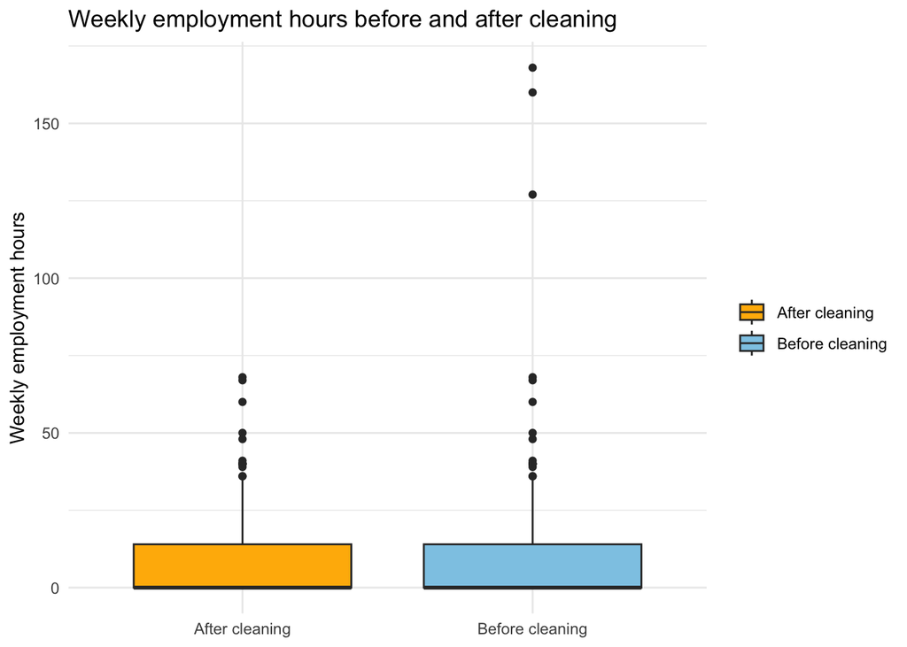

```r
library(tidyverse)
raw <- read_csv("DATA2X02_2026_2_survey_clean.csv", show_col_types = FALSE)

df <- raw %>%
  rename(
    age          = `What is your age? (years)`,
    height       = `What is your approximate height? (cms)`,
    intl_dom     = `Are you an International or Domestic student?`,
    unit         = `Are you in DATA2002 or DATA2902?`,
    grade1001    = `What grade did you get in DATA1001/1901 (or equivalent unit)?`,
    gradehope    = `What grade do you hope to get in DATA2002/2902?`,
    assess       = `When it comes to uni assessments, what do you tend to do?`,
    commute      = `On average, how long does it take you to get to campus? (mins) [1 direction]`,
    pay_rent     = `Do you pay rent?`,
    rent_amt     = `On average, how much rent do you pay per week? (dollars)`,
    work_hrs     = `On average, how many hours a week do you spend in paid employment? (hours)`,
    sleep_hrs    = `On average, how many hours sleep do you get per night? (hours)`,
    music        = `What is your favourite type of music?`,
    aliens       = `Do you believe in the existence of aliens? (Extraterrestial life)`,
    water        = `On average, how much water do you drink in a day? (litres)`,
    n_lang       = `How many spoken languages can you speak fluently?`,
    multitask    = `Do you multi-task in lectures? (ie do other tasks concurrently)`
  ) %>%
  filter(assess != "Other") %>%
  mutate(assess = factor(assess, levels = c("Immediately", "Gradually", "Cram")),
         multitask = factor(multitask, levels = c("no", "yes"), labels = c("No", "Yes")))

threshold <- 70

df_clean <- df %>% filter(work_hrs <= threshold)

ggplot(bind_rows(
    df %>% mutate(stage = "Before cleaning"),
    df_clean %>% mutate(stage = "After cleaning")
  ),
  aes(x = stage, y = work_hrs, fill = stage)) +
  geom_boxplot() +
  scale_fill_manual(values = c("Before cleaning" = "#8ecae6", "After cleaning" = "#ffb703")) +
  labs(
    title = "Weekly employment hours before and after cleaning",
    x = NULL, y = "Weekly employment hours", fill = NULL
  ) +
  theme_minimal()
```

```r
write_csv(df_clean, "survey_cleaned.csv")
```

# 2 Results

## 2.2 RQ2

### 2.2.1 Step 1: Data import & cleaning (multitasking vs cramming)

```r
library(tidyverse)
```

```r
survey <- read_csv("survey_cleaned.csv")
# Keep only the variables needed for RQ2, and derive a binary
# "Cram vs Not Cram" version of `assess` so the test lines up with the RQ
# statement ("multitasking and cramming"), rather than the original 3-level
# assessment-style variable (Gradually / Immediately / Cram).
rq2_data <- survey %>%
  select(assess, multitask) %>%
  drop_na(assess, multitask) %>%
  mutate(
    assess    = factor(assess, levels = c("Gradually", "Immediately", "Cram")),
    is_cram   = if_else(assess == "Cram", "Cram", "Not Cram"),
    is_cram   = factor(is_cram, levels = c("Not Cram", "Cram")),
    multitask = factor(multitask, levels = c("No", "Yes"))
  )

glimpse(rq2_data)
```

```
Rows: 661
Columns: 3
$ assess    <fct> Gradually, Gradually, Cram, Gradually, Gradually, Gradually,…
$ multitask <fct> No, Yes, No, Yes, Yes, No, No, No, Yes, No, Yes, Yes, Yes, N…
$ is_cram   <fct> Not Cram, Not Cram, Cram, Not Cram, Not Cram, Not Cram, Not …
```

We only select `assess` and `multitask` (not the whole cleaned dataset), and only drop rows missing on these two columns — so this subsetting is specific to RQ2 and doesn’t discard rows that are unusable for other RQs. `assess` is collapsed from 3 levels into a binary `is_cram` variable to match the RQ2 question directly (cram vs not cram).

### 2.2.2 Step 2: Exploratory visualisation (multitasking vs cramming)

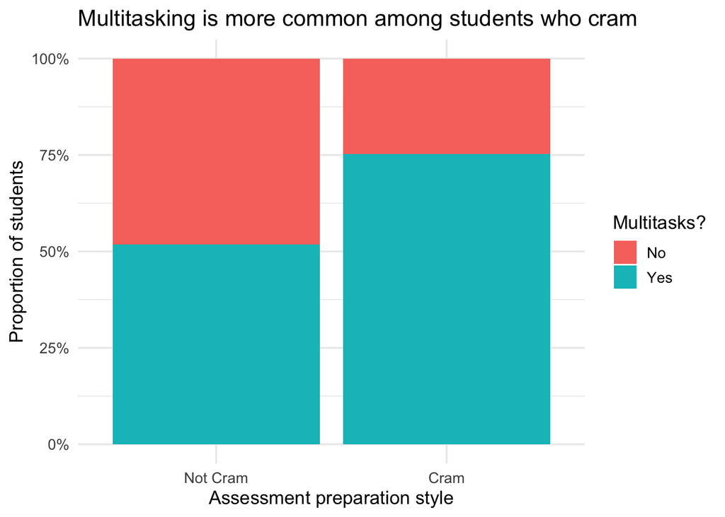

Proportion of students who multitask, by cramming behaviour

```r
rq2_data %>%
  count(is_cram, multitask) %>%
  group_by(is_cram) %>%
  mutate(prop = n / sum(n)) %>%
  ggplot(aes(x = is_cram, y = prop, fill = multitask)) +
  geom_col(position = "fill") +
  scale_y_continuous(labels = scales::percent) +
  labs(
    x = "Assessment preparation style",
    y = "Proportion of students",
    fill = "Multitasks?",
    title = "Multitasking is more common among students who cram"
  ) +
  theme_minimal(base_size = 13)
```

Supplementary (optional) — the same relationship broken down by the original 3-level `assess` variable, useful as a descriptive figure even though the formal test uses the collapsed 2x2 version:

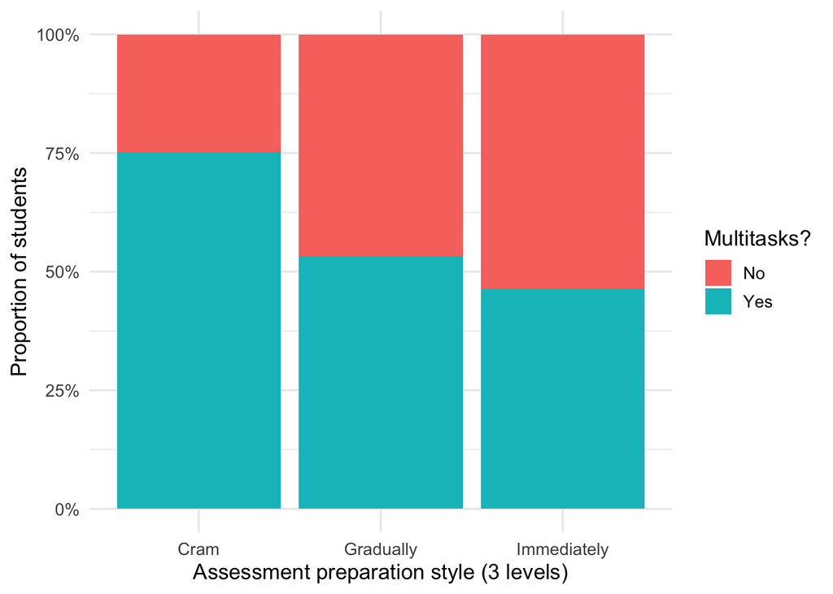

```r
survey %>%
  drop_na(assess, multitask) %>%
  count(assess, multitask) %>%
  group_by(assess) %>%
  mutate(prop = n / sum(n)) %>%
  ggplot(aes(x = assess, y = prop, fill = multitask)) +
  geom_col(position = "fill") +
  scale_y_continuous(labels = scales::percent) +
  labs(x = "Assessment preparation style (3 levels)",
       y = "Proportion of students", fill = "Multitasks?") +
  theme_minimal(base_size = 13)
```

Both plots show the same pattern: the multitasking rate is visibly higher among students who cram (~75%) than among those who don’t (~52% “Gradually”, ~46% “Immediately”). This motivates formally testing the association in the next step.

### 2.2.3 Step 3: Hypothesis test — Chi-squared test of independence

**H:** $H_0$: multitasking behaviour is independent of cramming behaviour. $H_1$: multitasking behaviour is *not* independent of cramming behaviour.

```r
cram_tab <- table(rq2_data$is_cram, rq2_data$multitask)
cram_tab
```

```
            No Yes
  Not Cram 262 282
  Cram      29  88
```

**A (assumptions):** The chi-squared test of independence requires (i) independent observations (one row per student — reasonable here, no student appears twice in the survey) and (ii) expected cell counts $\geq 5$ in every cell of the contingency table.

```r
chi_test <- chisq.test(cram_tab, correct = FALSE)
chi_test$expected
```

```
                  No       Yes
  Not Cram 239.49168 304.50832
  Cram      51.50832  65.49168
```

All four expected counts are well above 5 (minimum ≈ 51.5), so the chi-squared approximation is valid here — there is no need to fall back on Fisher’s exact test or a Yates continuity correction.

**T & P (test statistic & p-value):**

```r
chi_test
```

```
    Pearson's Chi-squared test

data:  cram_tab
X-squared = 21.351, df = 1, p-value = 3.825e-06
```

```r
# Effect size (Cramer's V), to accompany the p-value
n <- sum(cram_tab)
cramers_v <- sqrt(unname(chi_test$statistic) / n)
cramers_v
```

```
[1] 0.1797235
```

Observed: $\chi^2 = 21.35$, $df = 1$, $p \approx 3.8\times10^{-6}$, Cramér’s $V \approx 0.18$ (small-to-moderate association).

**C (conclusion with limitations):** There is very strong evidence ($p < 0.001$) against the null hypothesis of independence: students who cram are considerably more likely to multitask (75.2%) than students who don’t (51.8%). However:

1. This is an observational, self-selected survey sample — voluntary response bias means busier or more disorganised students may be over- or under-represented.
2. “Cram” and “multitask” are both self-reported and self-interpreted categories, which may not be applied consistently across respondents.
3. Association is not causation — a third factor (e.g. workload, procrastination tendency) could plausibly drive both behaviours.
4. Collapsing `assess` from 3 levels to 2 (Cram vs Not Cram) loses some information about the distinction between “Gradually” and “Immediately” preparers.

## 2.3 RQ3: Do students who multitask during lectures spend a different average number of hours per week in paid employment compared with students who do not multitask?

```r
rq3_summary <- df_clean %>%
  filter(!is.na(work_hrs), !is.na(multitask)) %>%
  group_by(multitask) %>%
  summarise(
    n = n(),
    mean = mean(work_hrs),
    median = median(work_hrs),
    sd = sd(work_hrs),
    Q1 = quantile(work_hrs, 0.25),
    Q3 = quantile(work_hrs, 0.75),
    min = min(work_hrs),
    max = max(work_hrs)
  )

knitr::kable(rq3_summary)
```

Table 1: Summary statistics of weekly paid employment hours by multitasking status.

| multitask | n | mean | median | sd | Q1 | Q3 | min | max |
| --- | --- | --- | --- | --- | --- | --- | --- | --- |
| No | 291 | 6.230240 | 0 | 10.38726 | 0 | 11.5 | 0 | 68 |
| Yes | 370 | 8.024324 | 1 | 10.73742 | 0 | 15.0 | 0 | 60 |

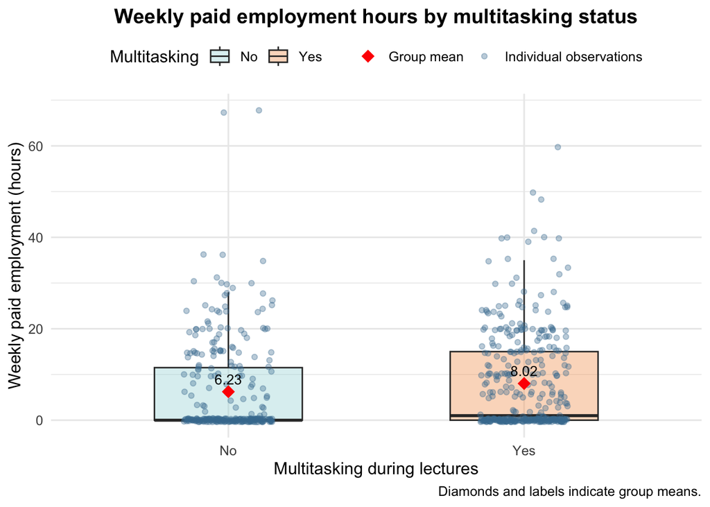

Figure 1: Distribution of weekly paid employment hours by multitasking status.

```r
df_clean %>%
  filter(!is.na(work_hrs), !is.na(multitask)) %>%
  ggplot(aes(x = multitask, y = work_hrs)) +

  geom_boxplot(
    aes(fill = multitask),
    width = 0.5,
    outlier.shape = NA,
    alpha = 0.4
  ) +

  geom_jitter(
    aes(colour = "Individual observations"),
    position = position_jitter(
      width = 0.15,
      seed = 123
    ),
    alpha = 0.35,
    size = 1.5
  ) +

  stat_summary(
    aes(colour = "Group mean"),
    fun = mean,
    geom = "point",
    shape = 18,
    size = 4
  ) +

  stat_summary(
    fun = mean,
    geom = "text",
    aes(label = after_stat(round(y, 2))),
    vjust = -0.75,
    size = 3.5
  ) +

  scale_fill_manual(
    name = "Multitasking",
    values = c(
      "No" = "#A8DADC",
      "Yes" = "#F4A261"
    )
  ) +

  scale_colour_manual(
    name = NULL,
    values = c(
      "Individual observations" = "#457B9D",
      "Group mean" = "red"
    )
  ) +

  labs(
    x = "Multitasking during lectures",
    y = "Weekly paid employment (hours)",
    title = "Weekly paid employment hours by multitasking status",
    caption = "Diamonds and labels indicate group means."
  ) +

  theme_minimal(base_size = 12) +
  theme(
    plot.title = element_text(face = "bold", hjust = 0.5),
    legend.position = "top"
  )
```

# 3 Conclusion

# 4 AI Usage Statement

# 5 ISI Professional Ethics Statement

# 6 References